# Multivariable Analysis HW-1

工管四 B06701235 黃亞婕

2021/03/14

```r
library(rstan)
library(rethinking)
library(splines)
```

## Q1.

#### 1.

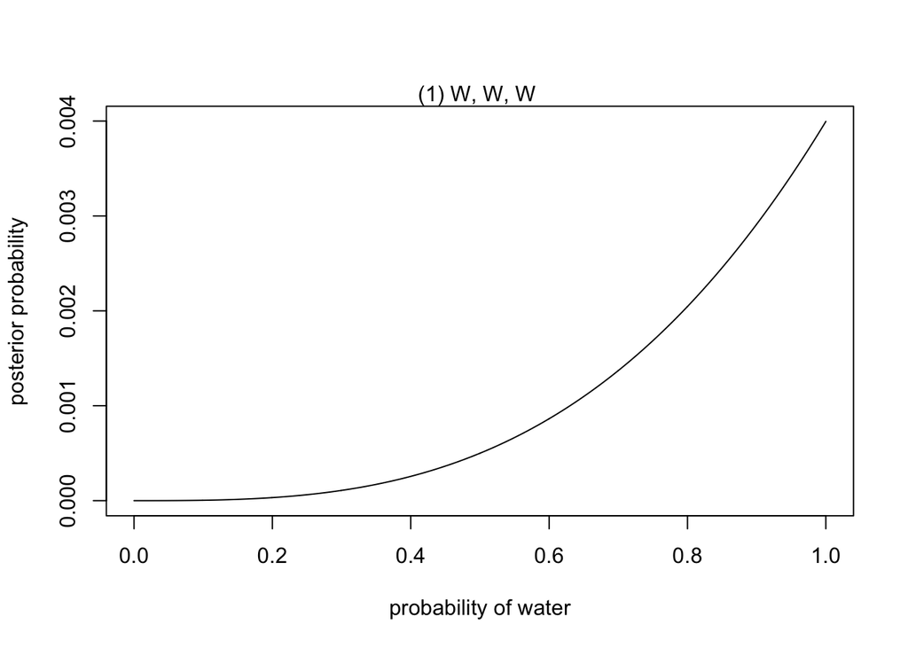

```r
p_grid = seq(from=0, to=1, length.out=1000)
prob_p = 1
likelihood <- dbinom(3, size = 3, prob = p_grid)
un_std_posterior <- prob_p * likelihood
posterior <- un_std_posterior / sum(un_std_posterior)
plot(p_grid, posterior, type = "l", xlab = "probability of water", ylab = "posterior probability")
mtext("(1) W, W, W ")
```

#### 2.

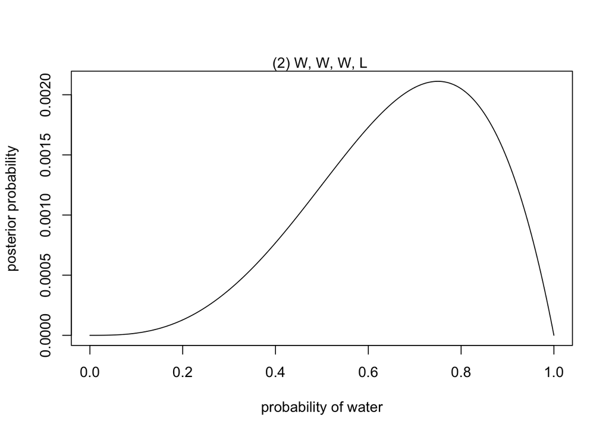

```r
p_grid = seq(from=0, to=1, length.out=1000)
prob_p = 1
likelihood <- dbinom(3, size = 4, prob = p_grid)
un_std_posterior <- prob_p * likelihood
posterior <- un_std_posterior / sum(un_std_posterior)
plot(p_grid, posterior, type = "l", xlab = "probability of water", ylab = "posterior probability")
mtext("(2) W, W, W, L ")
```

#### 3.

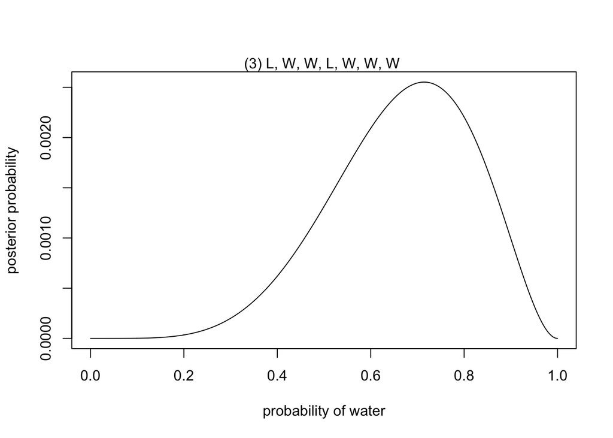

```r
p_grid = seq(from=0, to=1, length.out=1000)
prob_p = 1
likelihood <- dbinom(5, size = 7, prob = p_grid)
un_std_posterior <- prob_p * likelihood
posterior <- un_std_posterior / sum(un_std_posterior)
plot(p_grid, posterior, type = "l", xlab = "probability of water", ylab = "posterior probability")
mtext("(3) L, W, W, L, W, W, W ")
```

## Q2.

#### 1.

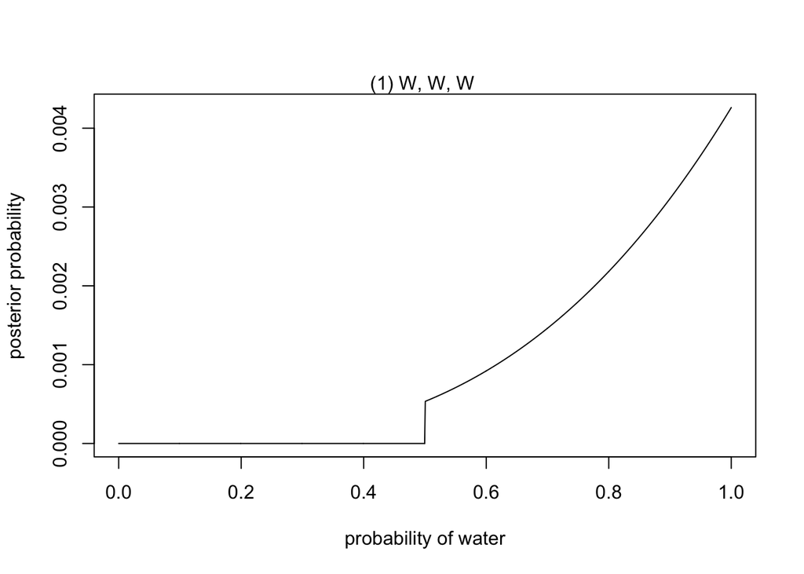

```r
p_grid = seq(from=0, to=1, length.out=1000)
prob_p = ifelse(p_grid < 0.5, 0, 1)
likelihood <- dbinom(3, size = 3, prob = p_grid)
un_std_posterior <- prob_p * likelihood
posterior <- un_std_posterior / sum(un_std_posterior)
plot(p_grid, posterior, type = "l", xlab = "probability of water", ylab = "posterior probability")
mtext("(1) W, W, W ")
```

#### 2.

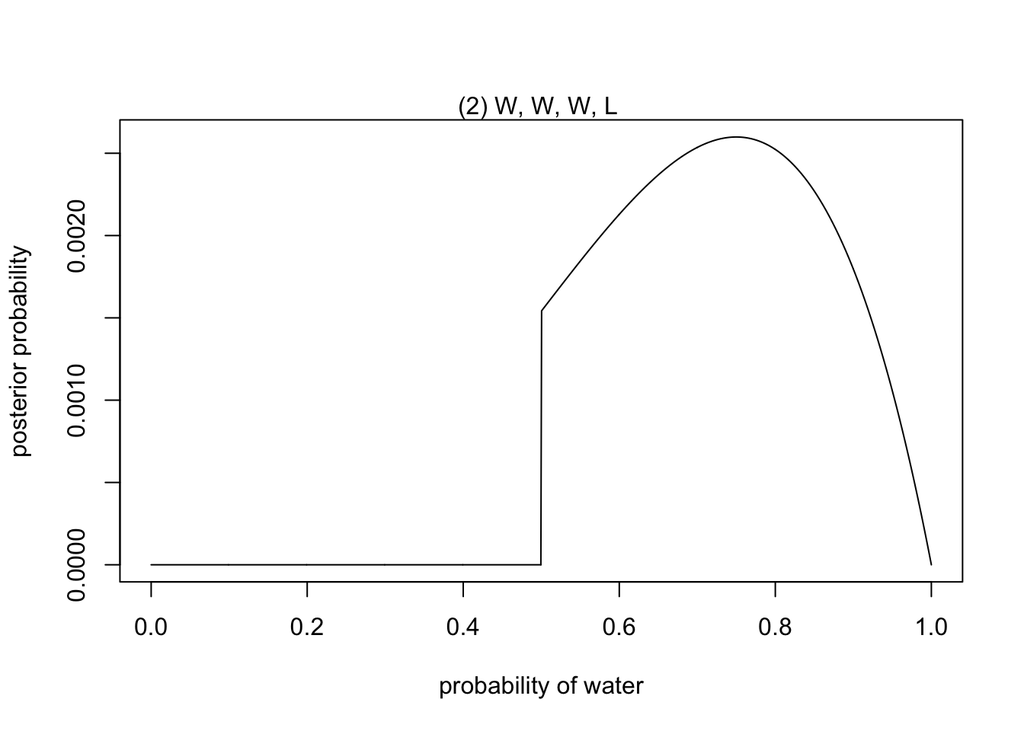

```r
p_grid = seq(from = 0, to = 1, length.out = 1000)
prob_p = ifelse(p_grid < 0.5, 0, 1)
likelihood <- dbinom(3, size = 4, prob = p_grid)
un_std_posterior <- prob_p * likelihood
posterior <- un_std_posterior / sum(un_std_posterior)
plot(p_grid, posterior, type = "l", xlab = "probability of water", ylab = "posterior probability")
mtext("(2) W, W, W, L ")
```

#### 3.

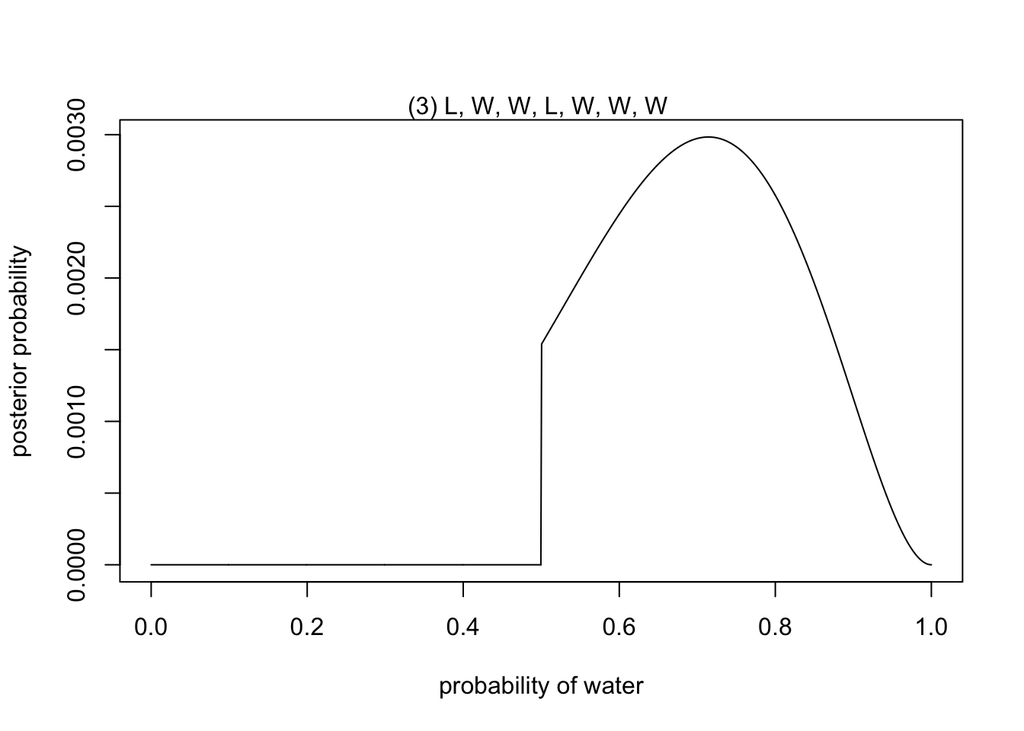

```r
p_grid = seq(from = 0, to = 1, length.out = 1000)
prob_p = ifelse(p_grid < 0.5, 0, 1)
likelihood <- dbinom(5, size = 7, prob = p_grid)
un_std_posterior <- prob_p * likelihood
posterior <- un_std_posterior / sum(un_std_posterior)
plot(p_grid, posterior, type = "l", xlab = "probability of water", ylab = "posterior probability")
mtext("(3) L, W, W, L, W, W, W ")
```

## Q3.

#### - Without Birth Data

```r
likelihood <- c(0.8, 1 - 0.65)
prior = 0.5
unstd_post <- prior * likelihood
posterior<- unstd_post / sum(unstd_post)
posterior[1]
```

```
## [1] 0.6956522
```

The posterior probability that your panda is species A is **0.6956522**.

#### - With Birth Data

此題需使用其他題目的數據，故由前幾題的數據先算出其 prior，再利用 prior 算出考慮 Birth Data 後的 posterior。

```r
p_A = 0.1
p_B = 0.2

likelihood <- c(
  p_A * (1 - p_A),
  p_B * (1 - p_B)
)

prior <- posterior
unstd_posterior2 <- prior * likelihood
posterior_2 <- unstd_posterior2 / sum(unstd_posterior2)
posterior_2[1]
```

```
## [1] 0.5625
```

After redoing the calculation, the posterior probability changed to **0.5625**.

## Q4.

首先使用 birth1 和 birth2 計算出 boys 出現的 posterior probability。再利用`sample()` 函數對母體進行抽樣，並以`rbinom()`函數模擬 10000 replicates of 200 births，最後使用`dens()`來畫出 simulate birth 的分佈，並觀察其與 actual count (111 boys) 的關係。

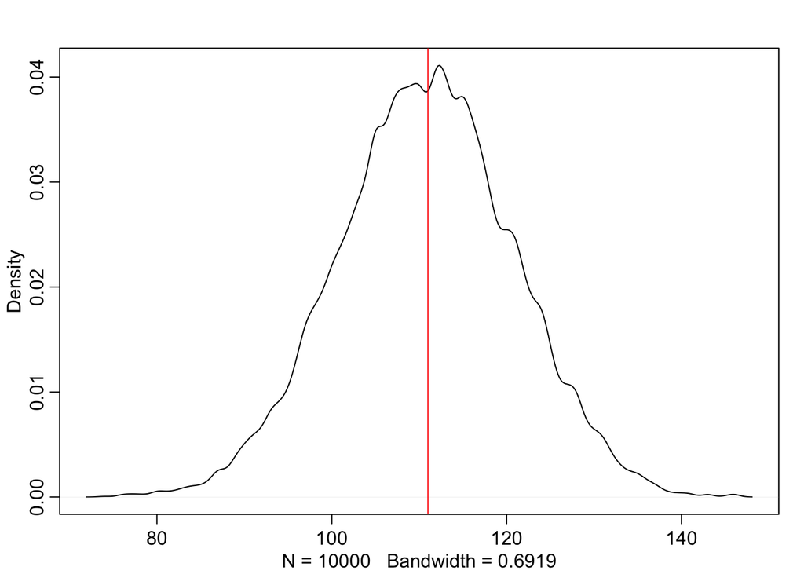

```r
birth1 <- c(1,0,0,0,1,1,0,1,0,1,0,0,1,1,0,1,1,0,0,0,1,0,0,0,1,0,
            0,0,0,1,1,1,0,1,0,1,1,1,0,1,0,1,1,0,1,0,0,1,1,0,1,0,0,0,0,0,0,0,
            1,1,0,1,0,0,1,0,0,0,1,0,0,1,1,1,1,0,1,0,1,1,1,1,1,0,0,1,0,1,1,0,
            1,0,1,1,1,0,1,1,1,1)
birth2 <- c(0,1,0,1,0,1,1,1,0,0,1,1,1,1,1,0,0,1,1,1,0,0,1,1,1,0,
            1,1,1,0,1,1,1,0,1,0,0,1,1,1,1,0,0,1,0,1,1,1,1,1,1,1,1,1,1,1,1,1,
            1,1,1,0,1,1,0,1,1,0,1,1,1,0,0,0,0,0,0,1,0,0,0,1,1,0,0,1,0,0,1,1,
            0,0,0,1,1,1,0,0,0,0)

num_boys = sum(birth1) + sum(birth2)
size = length(birth1) + length(birth2)

p_grid <- seq(from = 0, to = 1, length.out = 1000)
prior = 1
likelihood <- dbinom(num_boys, size, prob = p_grid)
unstd_posterior <- likelihood * prior
posterior <- unstd_posterior / sum(unstd_posterior)

samples <- sample(p_grid, prob = posterior, size = 10000, replace = TRUE)
simulate <- rbinom(10000, size = 200, samples)
dens(simulate)
abline(v = 111 , col = "red")
```

The observed number of boys (紅色的直線) 在我們畫出的predicted numbers of boys 模型中非常接近其平均數，此模型 fits the observed data well。

## Q5.

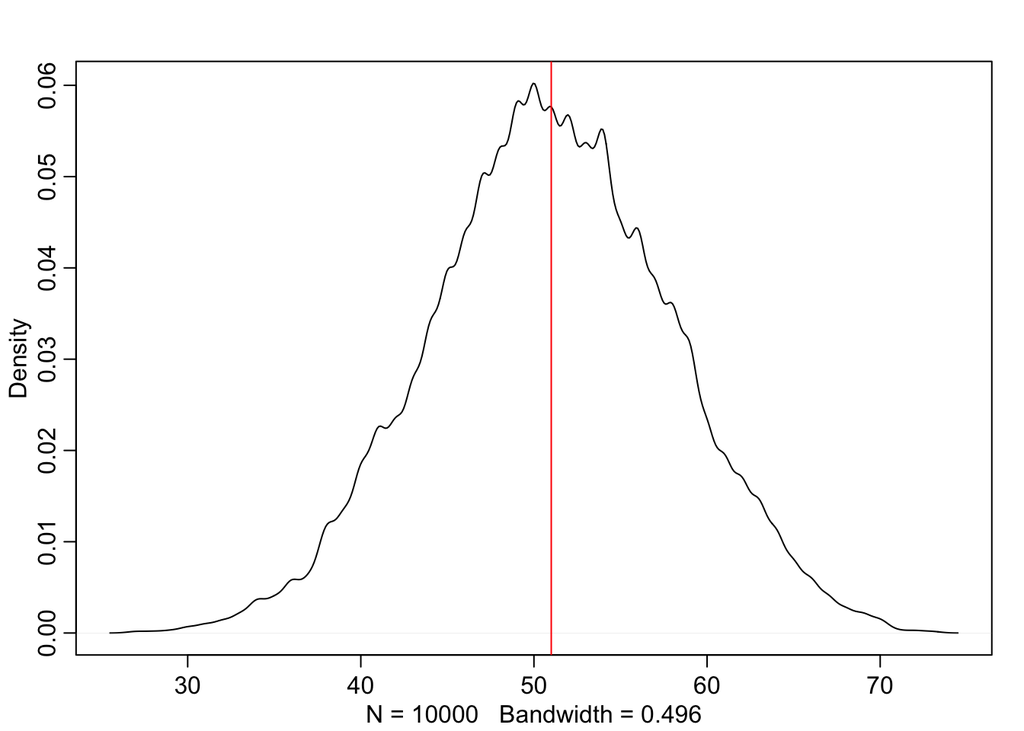

```r
num_boys_1 = sum(birth1)
size_1 = length(birth1)

p_grid <- seq(from = 0, to = 1, length.out = 1000)
prior_1 = 1
likelihood_1 <- dbinom(num_boys_1, size_1, prob = p_grid)
unstd_posterior_1 <- likelihood_1 * prior_1
posterior_1 <- unstd_posterior_1 / sum(unstd_posterior_1)

samples <- sample(p_grid, prob = posterior_1, size = 10000, replace = TRUE)
simulate_1 <- rbinom(10000, size = 100, samples)
dens(simulate_1)
abline(v = num_boys_1, col = "red")
```

## Q6.

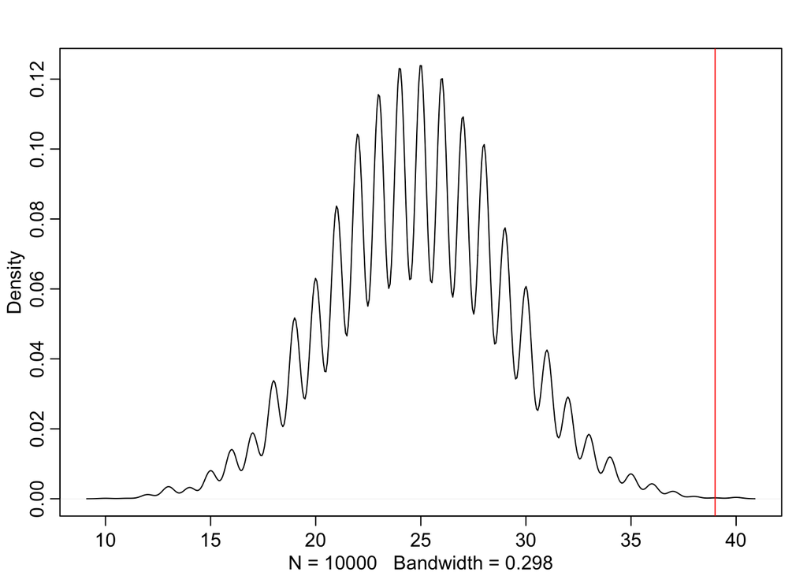

```r
# Count the number of first borns who were girls and simulate 10,000 times.
num_girls = sum(birth1 == 0)
sim_girl = rbinom(10000, size = num_girls, prob = samples)
dens(sim_girl)

#  Compare the counts of boys to the actual observed count of boys following girls.
girl_boy <- sum(birth2 [ birth1 == 0 ])
abline(v = girl_boy, col = "red")
```

模型低估了第一胎是女嬰後的第二胎為男嬰的數量，預測值和實際狀況偏離許多，可知此模型 doesn’t fit，故可推測第一胎和第二胎的性別並非獨立。

## Q7.

#### part (a)

The relationship between height (cm) and the natural logarithm of weight (log-kg).

```r
data(Howell1)
d <- Howell1

interpret <- alist(
  height ~ dnorm( mu, sigma ),
  mu <- a + b * log(weight),
  a ~ dnorm(178, 100),
  b ~ dnorm(0, 100),
  sigma ~ dunif(0, 50)
  )
m <- map(interpret, data = d)
precis(m)
```

|  | mean | sd | 5.5% | 94.5% |
| --- | --- | --- | --- | --- |
| a | -23.784355 | 1.3351200 | -25.918135 | -21.650576 |
| b | 47.075362 | 0.3825464 | 46.463979 | 47.686745 |
| sigma | 5.134715 | 0.1556693 | 4.885925 | 5.383504 |

Interpretation:

要以 β 來進行估計比較不直觀，因為我們是 log-kg 而非一般 kg 來計算。根據上述資料，每增加 1 log-kg 的重量，會增加 47 cm 的身高。

#### part (b)

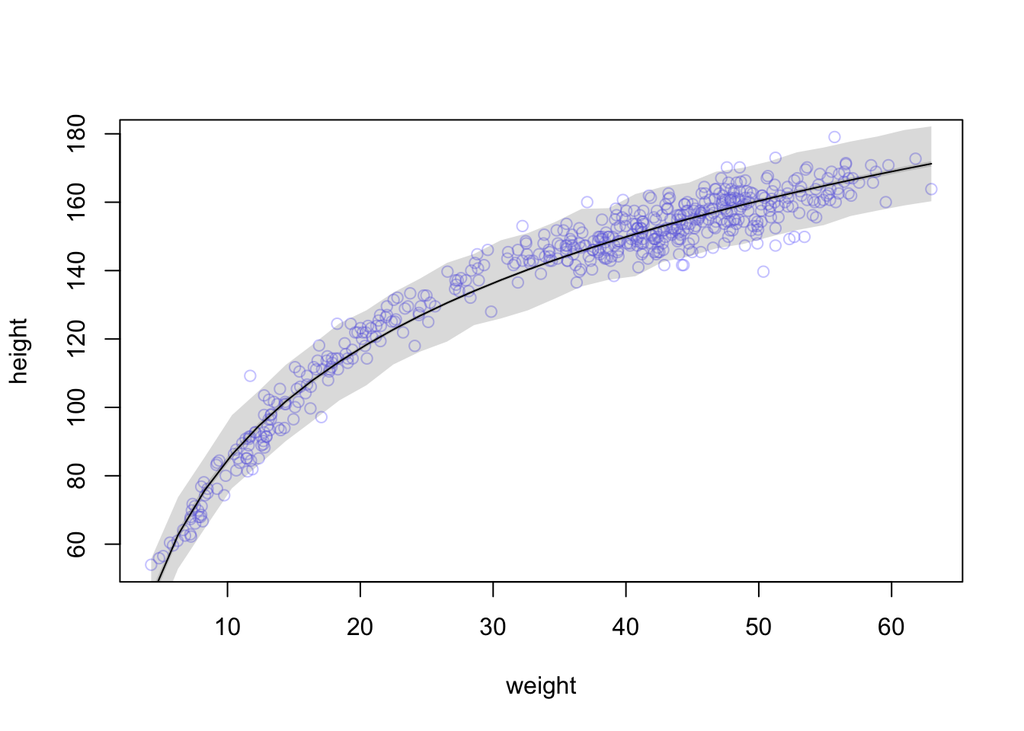

```r
plot( height ~ weight , data = Howell1 , col = col.alpha(rangi2,0.4) )

# Calculate the predicted mean height and 97% interval for the mean and predicted height
weight_seq <- seq(from = min(d$weight), to = max(d$weight), length.out = 30)
mu <- link(m, data = data.frame(weight = weight_seq))

mu_mean <- apply(mu , 2 , mean)
mu_HPDI <- apply(mu , 2 , HPDI , prob = 0.97)
sim_height <- sim(m, data = list(weight = weight_seq))
height_HPDI <- apply(sim_height , 2 , HPDI, prob = 0.97)

# Plot the predicted mean height and 97% interval for the mean
lines(weight_seq, mu_mean)
shade(mu_HPDI, weight_seq)

# Plot the 97% interval for the predicted heights
shade(height_HPDI , weight_seq)
```

## Q8.

```r
data("cherry_blossoms")
d <- cherry_blossoms

# 取 doy 和 temp 皆不為空值的
d2 <- d[complete.cases(d), ]
```

#### Linear Model

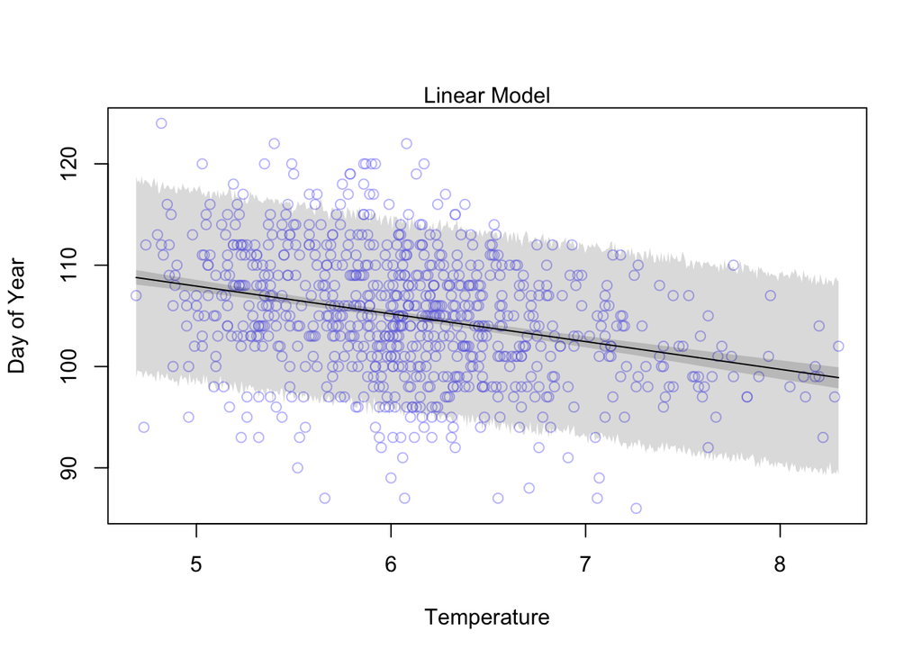

```r
mean_temp <- mean(d2$temp)
linear_model <- quap(
  alist(
    D ~ dnorm( mu, sigma ),
    mu <- a + b * (temp-mean_temp) ,
    a ~ dnorm( 100, 10 ),
    b ~ dnorm( 0, 1 ),
    sigma ~ dexp(1)
  ), data = list(D = d2$doy, temp = d2$temp)
)

# Calculate the predicted doy and 89% prediction interval
temp_seq <- seq( from = min(d2$temp) , to = max(d2$temp) , length.out = 500)
d3 <- list(temp = temp_seq)
mu <- link( linear_model , data = d3)

mu_mean <- apply(mu , 2 , mean )
mu_PI <- apply(mu , 2 , PI , 0.89)
doy_sim <- sim(linear_model , data = d3)
doy_PI <- apply( doy_sim, 2, PI, 0.89)

# Plot out the lines
plot(d2$temp , d2$doy, col = col.alpha(rangi2, 0.5) , xlab = "Temperature",  ylab  = "Day of Year")
lines( temp_seq , mu_mean)
shade( mu_PI, temp_seq)
shade( doy_PI , temp_seq)
mtext("Linear Model")
```

#### Polynomial Model (Quadratic)

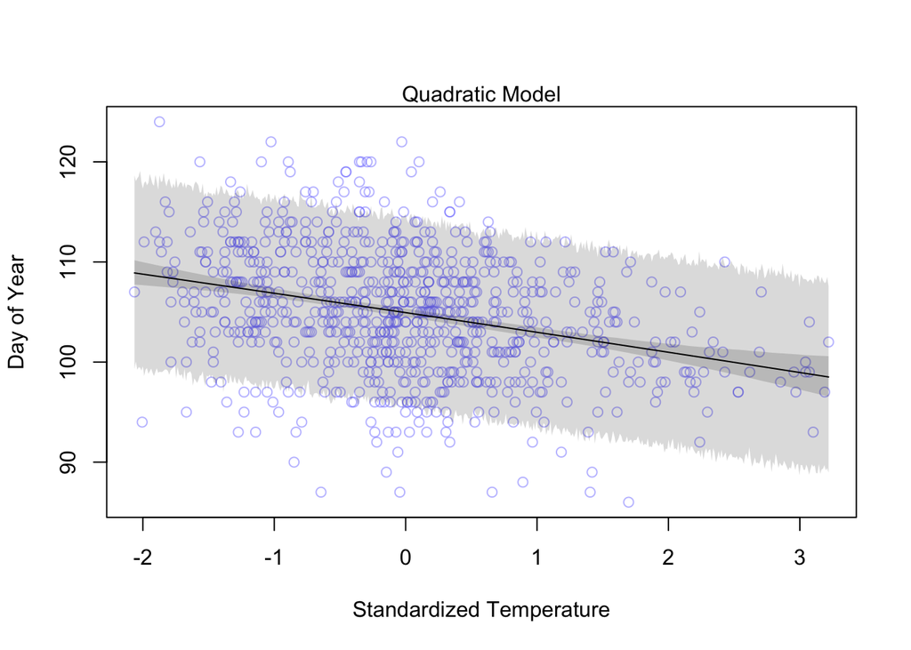

```r
# Standardize the predictor variable
d2$temp_std <- (d2$temp - mean_temp) / sd(d2$temp)

# Rewrite the Model
d2$temp_std2 <- d2$temp_std^2
qua_mdl <- quap(
  alist(
    D ~ dnorm( mu, sigma ),
    mu <- a + b1*temp_std + b2*temp_std2,
    a ~ dnorm( 100 , 10 ),
    b1 ~ dnorm( 0 , 1 ),
    b2 ~ dnorm(0 , 1),
    sigma ~ dexp(1)
  ), data=list(D = d2$doy, temp_std = d2$temp_std, temp_std2 = d2$temp_std2)
)

# Calculate the predicted doy and 89% prediction interval
temp_seq <- seq( from = min(d2$temp_std) , to = max(d2$temp_std) , length.out = 500)
d4 <- list(temp_std = temp_seq , temp_std2 = temp_seq^2)
mu <- link( qua_mdl , data = d4)

mu_mean <- apply(mu , 2 , mean )
mu_PI <- apply(mu , 2 , PI , prob = 0.89)
doy_sim <- sim(qua_mdl , data = d4)
doy_PI <- apply( doy_sim , 2 , PI , prob = 0.89)

# Plot out the lines

plot(doy ~ temp_std, data = d2, col = col.alpha(rangi2, 0.5), xlab = "Standardized Temperature", ylab = "Day of Year" )
lines(temp_seq , mu_mean)
shade( mu_PI , temp_seq)
shade( doy_PI , temp_seq)
mtext("Quadratic Model")
```

#### Spline Model

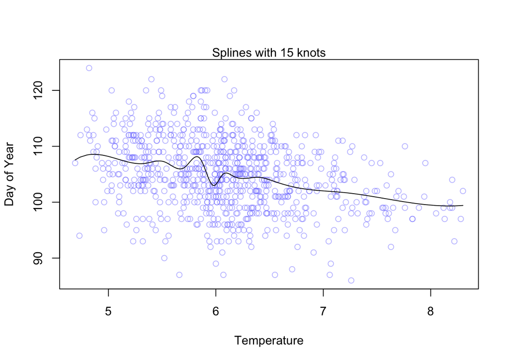

```r
data("cherry_blossoms")
d <- cherry_blossoms


d2 <- d[complete.cases(d), ]

num_knots <- 15
knot_list <- quantile( d2$temp, probs = seq(0, 1, length.out = num_knots ) )
B <- bs(d2$temp, knots=knot_list[-c(1, num_knots)],degree=3, intercept=TRUE)

spline_mdl <- quap(
  alist(
    D ~ dnorm( mu, sigma ),
    mu <- a + B %*% w,
    a ~ dnorm( 100, 10 ),
    w ~ dnorm( 0, 10 ),
    sigma ~ dexp(1)
  ),
  data = list( D = d2$doy , B = B) ,
  start = list( w = rep( 0 , ncol(B)))
)

mu <- link( spline_mdl , data = d2)
mu_mean <- apply ( mu , 2 , mean )
mu_PI <- apply ( mu , 2 , PI , prob = 0.89)
doy_sim <- sim ( spline_mdl , data = d2)
doy_PI <- apply( doy_sim , 2 , PI , prob = 0.89)

res <- data.frame(cbind(d2$doy , mu_mean , d2$temp))
res <- res[order(d2$temp), ]
with(res, plot(V3 , V1 , col = col.alpha(rangi2, 0.5) , xlab = "Temperature", ylab = "Day of Year" ))
with(res , lines(V3 , mu_mean))
mtext("Splines with 15 knots")
```

Interpretation:

上述三張圖型可看出 linear 和 polynomial 下的模型較為相似，而spline 的 regression line 比較 wiggly ，其在 6°C 時有一個大幅度的波動。相比之下，linear model已經能清楚地表示出溫度和開花天數的負相關關係。

## Q9.

首先在維基百科搜尋 LDS population in the States 並加入 data `WaffleDivorce` ，後將此欄位進行標準化。其次，利用 data 建立 multiple regression model。

```r
data(WaffleDivorce)
d <- WaffleDivorce

d$LDS <- c(0.0077, 0.0458, 0.0600, 0.0107, 0.0191, 0.0261, 0.0045, 0.0058, 0.0045, 0.0075, 0.0082, 0.0530, 0.2586, 0.0045, 0.0068, 0.0090, 0.0132, 0.0080, 0.0064, 0.0082, 0.0072, 0.0041, 0.0045, 0.0059, 0.0073, 0.0118, 0.0473, 0.0130, 0.0065, 0.0038, 0.0331, 0.0043, 0.0085, 0.0152, 0.0054, 0.0124, 0.0364,0.0041, 0.0040, 0.0080, 0.0120, 0.0077, 0.0125, 0.6632, 0.0074, 0.0113, 0.0380, 0.0096, 0.0047, 0.1170)
d$logLDS <- log(d$LDS)
d$std_LDS <- (d$logLDS - mean(d$logLDS)) / sd(d$logLDS)

mdl <- map(
  alist(
    Divorce ~ dnorm(mu,sigma),
    mu <- a + bR*Marriage + bA*MedianAgeMarriage + bM*std_LDS,
    a ~ dnorm(0,100),
    bA ~ dnorm(0,10),
    bR ~ dnorm(0,10),
    bM ~ dnorm(0,10),
    sigma ~ dunif(0,10)
  ),
  data=d )

precis( mdl )
```

|  | mean | sd | 5.5% | 94.5% |
| --- | --- | --- | --- | --- |
| a | 38.33959216 | 7.1222539 | 26.9568549 | 49.7223294 |
| bA | -1.12511493 | 0.2352603 | -1.5011064 | -0.7491235 |
| bR | 0.03291054 | 0.0847509 | -0.1025378 | 0.1683589 |
| bM | -0.63293733 | 0.2905949 | -1.0973641 | -0.1685106 |
| sigma | 1.37477879 | 0.1375408 | 1.1549621 | 1.5945955 |

Interpretation：

## Q10.

- AIC : *D$_{train}$ + 2p*，p 是在此模型中需要被預測的參數數目。
- DIC : *$\bar{D}$ + p$_{D}$ = $\bar{D}$ + ( $\bar{D}$ + $\hat{D}$ )* ，*$\bar{D}$* 是 posterior distribution of 偏差的平均，而 *$\hat{D}$* 是 posterior mean 的偏差。
- WAIC : -2( lppd - *p$_{WAIC}$*) = -2( $\sum_{i=1}^{N} log Pr(y_i)$ - $\sum_{i=1}^{N} V(y_i)$) ， Pr(y$_{i}$)是 likelihood of observation 在training sample 中的平均，V(y$_{i}$) 是 log-likelihood 在 training sample 中的變異數。

WAIC 是最 general 的 (WAIC > DIC > AIC)。若要轉為 DIC 須假設 posterior distribution 為 multivariate Gaussian 分佈；從 DIC 變 AIC，則要假設 prior 是 flat 的。三者皆需要有 in-sample training deviance 的估計與模型中 free parameters 數量的估計。